# Análise de tempo de execução e notação assintótica

Leitura recomendada: Capítulo 0 de [Dasgupta-Papadimitriou-Vazirani](http://algorithmics.lsi.upc.edu/docs/Dasgupta-Papadimitriou-Vazirani.pdf)

## Análise de tempo de execução

Uma maneira simplificada de analisar o tempo de execução de um algoritmo é contar o número de operações realizadas.

**Problema (Exp):**

- Entrada: Dois inteiros $n$ e $p \geq 0$
- Saída: $n^p$

```python
def potencia(n, p):
    r = 1 # 2 operacoes (acessar 1, =)
    i = 0 # 2 operacoes (acessar 0, =)
    while(i < p): # 3 operacao (ler i, ler p e comparar)
        r = r*n # 4 operacoes (ler r, ler n, =, *)
        i = i+1 # 3 operacoes (ler i, +, acessar 1,=)
    return r
```

```python
potencia(2,4)
```

```
16
```

O while roda para i=0, 1, 2,..., p-1.

Ou seja,

- i<p: $p+1$ vezes - $3(p+1)$ operações
- r = r*n: $p$ vezes - $4p$ operações
- i = i+1: $p$ vezes - $4p$ operações

Somando com as operações de r=1 e i=0, o número de operações total é $$ 4+3(p+1)+4p+4p = 11p+7. $$

Vamos conferir:

```python
def potenciaOperacoes(n, p):
    r = 1 # 2 operacoes (acessar 1, =)
    i = 0 # 2 operacoes (acessar 0, =)
    op = 7
    while(i < p): # 3 operacao (ler i, ler p e comparar)
        r = r*n # 4 operacoes (ler r, ler n, =, *)
        i = i+1 # 4 operacoes (ler i, +, acessar 1, =)
        op += 11
    print('Numero de operacoes '+str(op))
    print(str(11*p+7))
    return r
```

```python
potenciaOperacoes(2,30)
```

```
Numero de operacoes 337
337
```

```
1073741824
```

```python
def potencia2(n, p):
    r = 1 # 2 operacoes (acessar 1, =)
    op = 5
    while(p > 0): # 3 operacao (ler i, ler p e comparar)
        r = r*n # 4 operacoes (ler r, ler n, =, *)
        p = p-1 # 4 operacoes (ler p, -, 1, =)
        op += 11
    print(op)
    return r
```

```python
potencia2(2,30)
```

```
335
```

```
1073741824
```

Temos apenas 2 operações a menos!

*Exercício:* É possível dizer que se rodarmos na mesma máquina e na mesma entrada, o primeiro método vai demorar mais do que o segundo (mesmo que por uma quantidade insignificante de tempo)?

**Definição:** Um algoritmo é considerado **eficiente** se o número de operações realizado no pior caso é limitado por $(\textrm{tamanho da entrada})^k$ para algum $k\in\mathbb{N}$. (Mesmo que $k=10000000$!)

*Exercício:* Qual o tamanho da entrada para o **Problema (Exp)**? O algoritmo em potencia(n,p) é considerado eficiente?

Quando analisamos algoritmos, consideramos apenas o termo mais significativo no número de operações e ignoramos constantes multiplicativas.

Por exemplo, para $11p+7$, estamos apenas interessados no $p$.

Assim, ao compararmos $11p+7$ e $11p+5$, consideramos que os tempos de execução são equivalentes.

Isso quer dizer que nesse tipo de análise um algoritmo que roda em tempo $p$ e um que roda em tempo $11p$ são considerados igualmente eficientes.

Isso parece muito injusto. O que você acha? Veja abaixo os gráficos para esses dois tempos de execução.

```python
import sys
!{sys.executable} -m pip install numpy
!{sys.executable} -m pip install matplotlib
```

[output not shown]

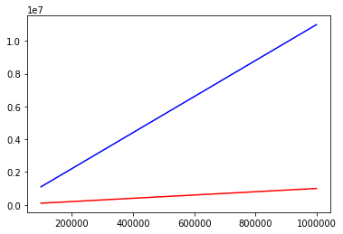

```python
import numpy as np
import matplotlib.pyplot as plt
%matplotlib inline
x = np.arange(100000,1000000,1000)
y1 = x
y2 = 11*x
plt.plot(x,y1,'r')
plt.plot(x,y2,'b')
```

Vamos ver agora um outro método.

Assuma que $p = 2^k$ para algum $k$ e $p\geq 1$:

```python
def potencia3(n,p):
    r = n
    i = 1
    op = 7
    while(i<p):
        r = r*r
        i = i*2
        op += 11
    print(op)
    return r
```

Vamos comparar como potencia2:

```python
potencia3(2,32)
potencia2(2,32)
```

```
62
357
```

```
4294967296
```

Quantas vezes o laço roda?

$i$ tem valores $1$, $2$, $4$,...$2^k = p$

```python
def potencia3Laco(n,p):
    r = n
    i = 1
    laco = 0
    while(i<p):
        r = r*r
        i = i*2
        laco = laco+1
        print(i)
    print('laco='+str(laco))
    return r
```

```python
potencia3Laco(2,32)
```

```
2
4
8
16
32
laco=5
```

```
4294967296
```

$32=2^k=p$ e note que $k = \lg p$. (Usamos $\lg$ para abreviar $\log_2$.)

Como isso se compara com potencia2?

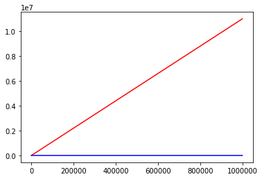

```python
x = np.arange(10,1000000,100)
y1 = 11*x+5
y2 = 11*np.log2(x)-4
plt.plot(x,y1,'r')
plt.plot(x,y2,'b')
```

Como você pode ver a diferença é muito mais drástica!

Vamos ver em seguida como comparar funções. Queremos definições onde $11p$ e $p$ sejam considerados equivalentes, mas $11\lg p$ seja considerado menor do que $p$.

# Funções assintóticas

Quanto consideramos uma função f <= uma função g?

Bom, já dissemos acima que consideramos apenas o termo mais significativo no número de operações e ignoramos constantes multiplicativas.

Como formalizar essa idéia? Vamos considerar funções $f(n)$ e $g(n)$.

Tentativa 1) Existe uma constante $A$ tal que $f(n) \leq A\cdot g(n)$

Funciona? Vamos comparar $f(n) = n+10000$ (em vermelho) e $g(n) = n^2$ (em azul).

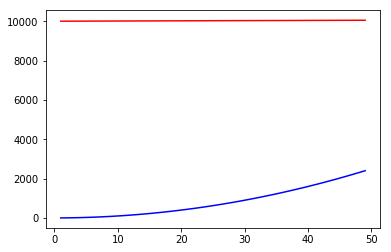

```python
x = np.arange(1,50)
f = x+10000;
g = x*x;
plt.plot(x,f,'r')
plt.plot(x,g,'b')
```

A função $g(n) = n^2$ ficou abaixo de $f(n) = n + 10000$?!?

Isso ocorreu porque estamos olhando para valores muito baixos de $n$.

Tentativa 2) Existem constantes $A$ e $N_0$ tais que $f(n) \leq A\cdot g(n)$ para todo $n\geq N_0$.

## Definição: $O$ ("<=" para funções)

Dizemos que uma função $f(n)$ é $O(g(n))$ (usamos a notação $f(n) = O(g(n))$) se

Existem constantes $A$ e $N_0$ tais que $f(n) \leq A\cdot g(n)$ para todo $n\geq N_0$.

### Exemplo

$f(n) = n^2 + n + 4$ e $g(n) = n^2$. Temos que $f(n) = O(g(n))$.

*Demonstração*: Para $N_0= 2$ e $A = 3$, temos que

- $f(n) = n^2+n+4 \leq n^2 + n^2 + 4$, pois $n\leq n^2$ para todo $n\geq 1$
- $2n^2+4\leq 2n^2 + n^2$, pois $4\leq n^2$ para todo $n\geq 2$
- Portanto, $f(n)\leq 3n^2 = A\cdot g(n)$ para todo $n\geq 2 = N_0$
- Assim, pela definição de $O$, mostramos que $f(n) = O(g(n))$.

Agora podemos definir ">=" e "=" para funções.

## Definição: $\Omega$ (">=" para funções)

Dizemos que uma função $f(n)$ é $\Omega(g(n))$ se

Existem constantes $A$ e $N_0$ tais que $g(n)\geq A\cdot g(n)$ para todo $n\geq N_0$.

### Exemplo

$n^2-n\log n = \Omega(n \log n)$

**Exercício:** É verdade que dadas funções $f(n)$ e $g(n)$ (ambas tendendo ao infinito com $n\to\infty$), temos que $f(n) = O(g(n))$ ou $f(n) = \Omega(g(n))$? Se sim, demonstre. Se não, mostre um contra-exemplo.

## Definição: $\Theta$ ("=" para funções)

Dizemos que uma função $f(n)$ é $\Theta(g(n))$ se

Existem constantes $A$ , $B$ e $N_0$ tais que $A\cdot g(n) \leq f(n) \leq B\cdot g(n)$ para todo $n\geq N_0$.

**Exercício:** Mostre que $f(n) = \Theta(g(n))$ se, e somente se, $f(n) = O(n)$ e $f(n) = \Omega(n)$.

## Notação $o$ e $\omega$

Vamos ver abaixo as noções de $<$ e $>$.

**Observação:** Não cai na P1.

## Definição: $o$ ("<" para funções)

Dizemos que uma função $f(n)$ é $o(g(n))$ se

Existem para toda constante $A>0$ existe $N_0$ tal que $f(n) \leq A\cdot g(n)$ para todo $n\geq N_0$.

O que isso quer dizer? Significa que, não importa o quão pequeno $A$ for (digamos $A=0.0000001$), a função $f(n)<\leq g(n)$ a partir de algum $n$. Ou seja, "$f$ é muito menor do que $g$"

Uma outra definição: $\lim_{n\to\infty} f(n)/g(n) = 0$

## Exemplo

$100 n^2 = o(n^3)$

Seja $A>0$. Temos que mostrar que existe $N_0$ tal que $n^3 \leq A\cdot n^3$ para todo $n\geq N_0$.

Defina $N_0:= \lceil 100/A\rceil$ ($100/A$ arredondando para cima). Temos que $100n^2 \leq A n^3$ se e somente se

$100 \leq An$ se e somente se

$n\geq 100/A$.

Assim, para como $n\geq N_0$, como $N_0\geq 100/A$, temos que $100 n^2\leq An^3$. Portanto, $100 n^2 = o(n^3)$.

## Exemplo

Seja $\epsilon >0$ um número inteiro positivo (imagine que $\epsilon=0.00001)$, temos que $\log n = o(n^\epsilon)$.

*Demonstração:* Vamos calcular $\lim_{n\to\infty} \frac{\log n}{n^\epsilon}$. Como $\log n \to \infty$ e $n^\epsilon \to\infty$ com $n\to\infty$, podemos aplicar o **Teorema de L'Hospital**: temos que $(\log n)' = 1/n$ e $(n^\epsilon)' = \epsilon(n^{\epsilon-1})$

$$\lim_{n\to\infty} \frac{\log n}{n^\epsilon} = \lim_{n\to\infty}\frac{1}{\epsilon \cdot n\cdot n^{\epsilon-1}} = \lim_{n\to\infty}\frac{1}{\epsilon \cdot n^{\epsilon}} = 0$$

**Exercício:** É verdade que se $f(n) = o(g(n))$ então $f(n) = O(g(n))$? Se sim, demonstre. Se não, mostre um contra-exemplo.

**Exercício:** É verdade que se $f(n) = O(g(n))$ então $f(n) = o(g(n))$? Se sim, demonstre. Se não, mostre um contra-exemplo.

## Definição: $\omega$ (">" para funções)

Dizemos que uma função $f(n)$ é $\omega(g(n))$ se

Existem para toda constante $A>0$ existe $N_0$ tal que $f(n) \geq A\cdot g(n)$ para todo $n\geq N_0$.

Uma outra definição: $\lim_{n\to\infty} f(n)/g(n) = \infty$

Ou seja, "$f$ é muito maior do que $g$"

# Resumo

Neste tópico, as competências principais são:

1. Identificar o termo dominante de uma função.
2. Comparar duas funções em termos de $O, \Omega, \Theta, o, \omega$.
3. Escrever demonstrações simples provando o relacionamento de duas funções.
4. Compreender o que as notações significam em termos práticos e teóricos